# plot_geopandas

### Python Geopandas package for shapefile management

Geopandas combines the ability of pandas & shapely for manipulating geographic data mainly vector data such as points, polylines, & polygons. Geopandas can read & write vector data in a variety of formats, including the ESRI shapefile format (.shp) & others such as KML (Keyhole Markup Language is a file format used to display geographic data in an Earth browser such as Google Earth), & GeoJSON (is a format for encoding a variety of geographic data structures).

### Installing Geopandas package

To install the latest version of GeoPandas, the conda package manager will be utilized. add a new environment variable named geopandas_stable. Start ubuntu terminal & enter the following commands:

```
 conda create --name geopandas_stable
```

Activate the geopandas_stable environment:

```
 conda activate geopandas_stable
```

Add & set conda-forge channel:

```
  conda config --env --add channels conda-forge
  conda config --env --set channel_priority strict
```

Install Geopandas package with python-3:

```
 conda install python=3 geopandas
```

Install Jupyter notebook and open the notebook

```
conda install notebook
jupyter-notebook
```

Import the Geopandas library:

```python
import geopandas as gpd
```

Check the Geopandas version:

```python
print(gpd.__version__)
```

```
0.12.2
```

You have successfully installed Geopandas if you receive the version number. Finally, for reading & writing shapefiles, you can use any Python Notebook or IDE, such as Jupyter-Notebook & Spyder.

### Reading & manipulating shapefile dataframes

Import the matplotlib library for visualization purposes:

```python
import matplotlib.pyplot as plt
from matplotlib.ticker import ScalarFormatter
```

There are two methods to read the data:

- You can download the compressed shapefiles from the above link to your local directory, extract it, & use this local directory to locate the path of the shapefiles
- Or you can directly read the compressed shapefiles from the above site if you are connected to internate

Load the shapefile using gpd.read_file function:

```python
zipfile_basins = "ETH_basins.zip"
ET_basin = gpd.read_file(zipfile_basins)
```

Inspect the attribute table of the data by typing:

```python
ET_basin
```

|  | AREA | PERIMETER | RIVERBASIN | RIVERBAS_1 | BASINNAME | layer | path | Basin_type | geometry |
| --- | --- | --- | --- | --- | --- | --- | --- | --- | --- |
| 0 | 2.000141e+11 | 2836371.545 | 5 | 4 | ABBAY | Abby | /home/yoni/Desktop/Yaredo_Grads/Basemap_exampl... | 1 | POLYGON ((35.75669 12.67180, 35.75921 12.67317... |
| 1 | 1.121677e+11 | 2050391.912 | 6 | 5 | AWASH | Awash | /home/yoni/Desktop/Yaredo_Grads/Basemap_exampl... | 1 | POLYGON ((39.52930 11.72403, 39.52891 11.72624... |
| 2 | 4.755561e+09 | 318650.138 | 7 | 6 | AYSHA | Aysha | /home/yoni/Desktop/Yaredo_Grads/Basemap_exampl... | 1 | POLYGON ((42.30811 10.99144, 42.32126 10.99586... |
| 3 | 7.572123e+10 | 2128499.780 | 8 | 7 | BARO AKOBO | Baro_akobo | /home/yoni/Desktop/Yaredo_Grads/Basemap_exampl... | 1 | POLYGON ((34.47938 10.83318, 34.48112 10.83473... |
| 4 | 6.524619e+10 | 1228197.473 | 4 | 3 | DENAKIL | Denakil | /home/yoni/Desktop/Yaredo_Grads/Basemap_exampl... | 1 | POLYGON ((39.37495 14.50856, 39.41100 14.52892... |
| 5 | 1.722588e+11 | 2006366.812 | 13 | 12 | GENALE DAWA | Genale_dawa1 | /home/yoni/Desktop/Yaredo_Grads/Basemap_exampl... | 1 | POLYGON ((41.13743 6.94134, 41.14177 6.93580, ... |
| 6 | 5.868187e+09 | 534670.622 | 2 | 1 | MEREB GASH | Mereb1 | /home/yoni/Desktop/Yaredo_Grads/Basemap_exampl... | 1 | POLYGON ((37.80309 14.70250, 37.91271 14.88540... |
| 7 | 7.969898e+10 | 1613036.102 | 9 | 8 | OGADEN | Ogaden | /home/yoni/Desktop/Yaredo_Grads/Basemap_exampl... | 1 | POLYGON ((43.31527 9.60498, 43.35539 9.58202, ... |
| 8 | 7.871230e+10 | 1832234.370 | 11 | 10 | OMO GIBE | Omo_gibe | /home/yoni/Desktop/Yaredo_Grads/Basemap_exampl... | 1 | POLYGON ((38.02335 8.93136, 38.03574 8.91034, ... |
| 9 | 5.298484e+10 | 1381422.016 | 12 | 11 | RIFT VALLY | Rift_valley | /home/yoni/Desktop/Yaredo_Grads/Basemap_exampl... | 1 | POLYGON ((38.40912 8.39296, 38.41411 8.39297, ... |
| 10 | 8.367317e+10 | 1468016.695 | 3 | 2 | TEKEZE | Tekeze | /home/yoni/Desktop/Yaredo_Grads/Basemap_exampl... | 1 | POLYGON ((39.40391 14.25409, 39.45916 14.23977... |
| 11 | 2.017996e+11 | 2336905.978 | 10 | 9 | WABI SHEBELE | Wabi_shebelle | /home/yoni/Desktop/Yaredo_Grads/Basemap_exampl... | 1 | POLYGON ((42.69533 9.58651, 42.69804 9.58040, ... |

Instead of displaying the entire dataframe, It is recommended to display only the first & last 5 rows of the dataframe using the .head() & .tail() built-in functions. To display the first 5 rows of the dataframe, type:

```python
ET_basin.head()
```

|  | AREA | PERIMETER | RIVERBASIN | RIVERBAS_1 | BASINNAME | layer | path | Basin_type | geometry |
| --- | --- | --- | --- | --- | --- | --- | --- | --- | --- |
| 0 | 2.000141e+11 | 2836371.545 | 5 | 4 | ABBAY | Abby | /home/yoni/Desktop/Yaredo_Grads/Basemap_exampl... | 1 | POLYGON ((35.75669 12.67180, 35.75921 12.67317... |
| 1 | 1.121677e+11 | 2050391.912 | 6 | 5 | AWASH | Awash | /home/yoni/Desktop/Yaredo_Grads/Basemap_exampl... | 1 | POLYGON ((39.52930 11.72403, 39.52891 11.72624... |
| 2 | 4.755561e+09 | 318650.138 | 7 | 6 | AYSHA | Aysha | /home/yoni/Desktop/Yaredo_Grads/Basemap_exampl... | 1 | POLYGON ((42.30811 10.99144, 42.32126 10.99586... |
| 3 | 7.572123e+10 | 2128499.780 | 8 | 7 | BARO AKOBO | Baro_akobo | /home/yoni/Desktop/Yaredo_Grads/Basemap_exampl... | 1 | POLYGON ((34.47938 10.83318, 34.48112 10.83473... |
| 4 | 6.524619e+10 | 1228197.473 | 4 | 3 | DENAKIL | Denakil | /home/yoni/Desktop/Yaredo_Grads/Basemap_exampl... | 1 | POLYGON ((39.37495 14.50856, 39.41100 14.52892... |

Similarly, to display the last 5 rows of the dataframe, type:

```python
ET_basin.tail()
```

|  | AREA | PERIMETER | RIVERBASIN | RIVERBAS_1 | BASINNAME | layer | path | Basin_type | geometry |
| --- | --- | --- | --- | --- | --- | --- | --- | --- | --- |
| 7 | 7.969898e+10 | 1613036.102 | 9 | 8 | OGADEN | Ogaden | /home/yoni/Desktop/Yaredo_Grads/Basemap_exampl... | 1 | POLYGON ((43.31527 9.60498, 43.35539 9.58202, ... |
| 8 | 7.871230e+10 | 1832234.370 | 11 | 10 | OMO GIBE | Omo_gibe | /home/yoni/Desktop/Yaredo_Grads/Basemap_exampl... | 1 | POLYGON ((38.02335 8.93136, 38.03574 8.91034, ... |
| 9 | 5.298484e+10 | 1381422.016 | 12 | 11 | RIFT VALLY | Rift_valley | /home/yoni/Desktop/Yaredo_Grads/Basemap_exampl... | 1 | POLYGON ((38.40912 8.39296, 38.41411 8.39297, ... |
| 10 | 8.367317e+10 | 1468016.695 | 3 | 2 | TEKEZE | Tekeze | /home/yoni/Desktop/Yaredo_Grads/Basemap_exampl... | 1 | POLYGON ((39.40391 14.25409, 39.45916 14.23977... |
| 11 | 2.017996e+11 | 2336905.978 | 10 | 9 | WABI SHEBELE | Wabi_shebelle | /home/yoni/Desktop/Yaredo_Grads/Basemap_exampl... | 1 | POLYGON ((42.69533 9.58651, 42.69804 9.58040, ... |

Alternatively, you can view a specific section of the dataframe by defining the row numbers, but keep in mind that Python counts starting from zero. For example, to display only the 3rd & 4th rows, you can type:

```python
ET_basin[3:5]
```

|  | AREA | PERIMETER | RIVERBASIN | RIVERBAS_1 | BASINNAME | layer | path | Basin_type | geometry |
| --- | --- | --- | --- | --- | --- | --- | --- | --- | --- |
| 3 | 7.572123e+10 | 2128499.780 | 8 | 7 | BARO AKOBO | Baro_akobo | /home/yoni/Desktop/Yaredo_Grads/Basemap_exampl... | 1 | POLYGON ((34.47938 10.83318, 34.48112 10.83473... |
| 4 | 6.524619e+10 | 1228197.473 | 4 | 3 | DENAKIL | Denakil | /home/yoni/Desktop/Yaredo_Grads/Basemap_exampl... | 1 | POLYGON ((39.37495 14.50856, 39.41100 14.52892... |

To find out the size of the dataframe, type:

```python
ET_basin.shape
```

```
(12, 9)
```

To obtain the row numbers or length of the dataframe, type:

```python
len(ET_basin)
```

```
12
```

To print the column names, type:

```python
ET_basin.columns
```

```
Index(['AREA', 'PERIMETER', 'RIVERBASIN', 'RIVERBAS_1', 'BASINNAME', 'layer',
       'path', 'Basin_type', 'geometry'],
      dtype='object')
```

To list the column’s contents:

```python
ET_basin.BASINNAME.values
```

```
array(['ABBAY', 'AWASH', 'AYSHA', 'BARO AKOBO', 'DENAKIL', 'GENALE DAWA',
       'MEREB GASH', 'OGADEN', 'OMO GIBE', 'RIFT VALLY', 'TEKEZE',
       'WABI SHEBELE'], dtype=object)
```

To know how the data is represented or stored in the dataframe, type:

```python
type(ET_basin)
```

```
geopandas.geodataframe.GeoDataFrame
```

In this example, each vector data is represented as GeoDataFrame

The $geometry$ column is the most essential of the columns & it contains the x-y coordinate values of the vector data. For instance, you can look at the values using .geometry function:

```python
print(ET_basin.geometry)
```

```
0     POLYGON ((35.75669 12.67180, 35.75921 12.67317...
1     POLYGON ((39.52930 11.72403, 39.52891 11.72624...
2     POLYGON ((42.30811 10.99144, 42.32126 10.99586...
3     POLYGON ((34.47938 10.83318, 34.48112 10.83473...
4     POLYGON ((39.37495 14.50856, 39.41100 14.52892...
5     POLYGON ((41.13743 6.94134, 41.14177 6.93580, ...
6     POLYGON ((37.80309 14.70250, 37.91271 14.88540...
7     POLYGON ((43.31527 9.60498, 43.35539 9.58202, ...
8     POLYGON ((38.02335 8.93136, 38.03574 8.91034, ...
9     POLYGON ((38.40912 8.39296, 38.41411 8.39297, ...
10    POLYGON ((39.40391 14.25409, 39.45916 14.23977...
11    POLYGON ((42.69533 9.58651, 42.69804 9.58040, ...
Name: geometry, dtype: geometry
```

You can use the following function to extract x-y coordinate values of a given polygon, In this case, the first polygon:

```python
def coord_lister(geom):
    coords = list(geom.exterior.coords)
    return(coords)
coordinates = ET_basin.geometry.apply(coord_lister)
Abbay_coord = coordinates[0]
```

Let’s look at the first ten x-y coordinate values of the first polygon:

```python
#len(Abbay_coord)
Abbay_coord[:10]
```

```
[(35.756690888078126, 12.671797097608444),
 (35.75921179031758, 12.673172165175462),
 (35.76174531616754, 12.674460456844615),
 (35.7643064966319, 12.675563955460834),
 (35.76690347742137, 12.676383429901467),
 (35.76954908459146, 12.676824219629998),
 (35.77224026615727, 12.676922403038853),
 (35.774962412059814, 12.676764711775403),
 (35.77771230490099, 12.676412056011529),
 (35.780480076318945, 12.675917364792335)]
```

You can use the geom_type function to get information about the geometry type (polygon, line, or point) of each data recorded in the dataframe:

```python
ET_basin.geom_type
```

```
0     Polygon
1     Polygon
2     Polygon
3     Polygon
4     Polygon
5     Polygon
6     Polygon
7     Polygon
8     Polygon
9     Polygon
10    Polygon
11    Polygon
dtype: object
```

To view the spatial extent or coverage of the shapefile, use the total_bounds function:

```python
ET_basin.total_bounds
```

```
array([33.00541327,  3.40510906, 47.99567693, 14.88539753])
```

The shapefile ranges from 33.00541327 to 47.99567693 longitudes & 3.40510906 to 14.88539753 latitudes

You may get a quick overview of the shape file by using the geometry values. For instance, to view the first data, you can use the code below:

```python
ET_basin.at[0,'geometry']
```

[output not shown]

### Shapefile plotting

Let’s now make a simple plot of the shapefile using plot() function:

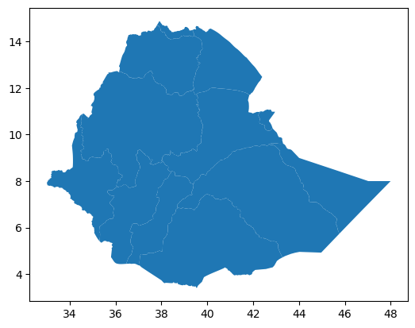

```python
ET_basin.plot()
```

Let’s colorize the map with the cmap function:

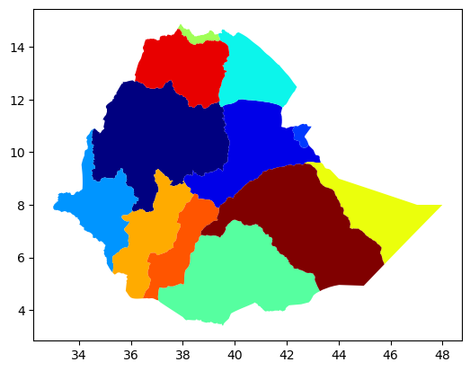

```python
ET_basin.plot(cmap='jet')
```

You can colorize the map based on a specific column, in this case, let’s use the BASINNAME column:

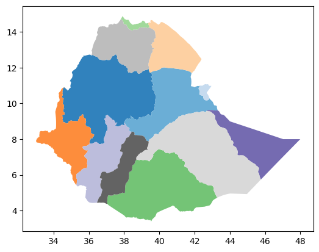

```python
 ET_basin.plot(cmap ='tab20c', column='BASINNAME')
```

You can also use the figsize option to change the plot size:

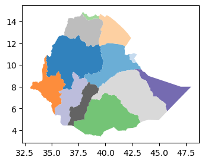

```python
 ET_basin.plot(cmap ='tab20c', column='BASINNAME', figsize=(4,3))
```

You can apply an edge color to each polygon in the shapefile using $edgecolor$ function:

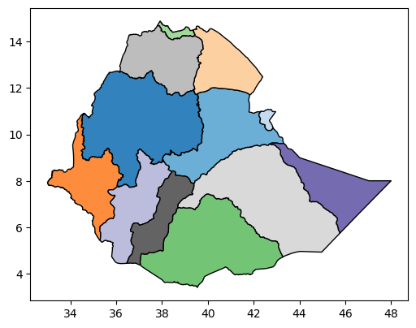

```python
ET_basin.plot(cmap ='tab20c', column='BASINNAME', figsize=(6,6), edgecolor='black')
```

You may also put a legend in the plot:

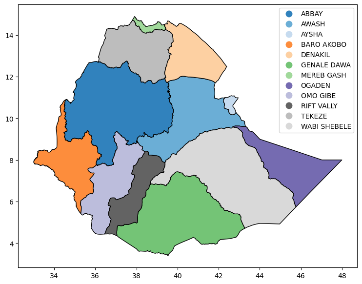

```python
  ET_basin.plot(cmap ='tab20c', column='BASINNAME', figsize=(9,7), edgecolor='black', legend=True)
```

However, using the matplotlib functions is a more convenient way to make plots:

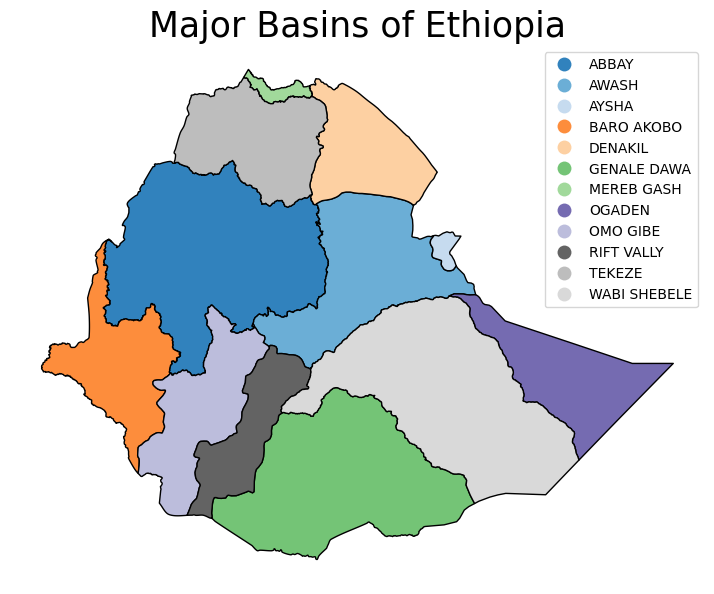

```python
fig, ax = plt.subplots(figsize=(9,7))
ET_basin.plot(alpha=1.0, cmap ='tab20c', column='BASINNAME', edgecolor='black', legend=True, ax=ax )
ax.set_title('Major Basins of Ethiopia', fontsize=25)
ax.set_axis_off()
plt.show()
```

You can also change the legend’s position:

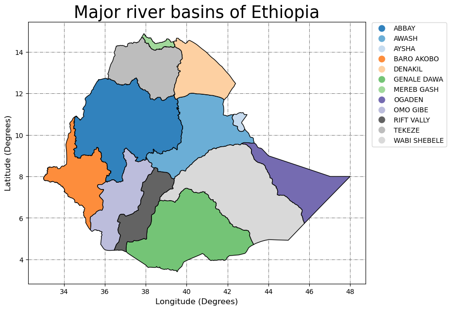

```python
fig, ax = plt.subplots(figsize=(9,7))
ET_basin.plot(alpha=1.0, cmap ='tab20c', column='BASINNAME', edgecolor='black', ax=ax, legend=True )
ax.set_title('Major river basins of Ethiopia', fontsize=25)
ax.set_axisbelow(True)
ax.yaxis.grid(color='gray', linestyle='dashdot')
ax.xaxis.grid(color='gray', linestyle='dashdot')
ax.set_xlabel("Longitude (Degrees)", fontsize=12)
ax.set_ylabel("Latitude (Degrees)", fontsize=12)
leg = ax.get_legend()
leg.set_bbox_to_anchor((1.25,1.01))
plt.show()
```

Plots can be saved as image files using the plt. savefig() function:

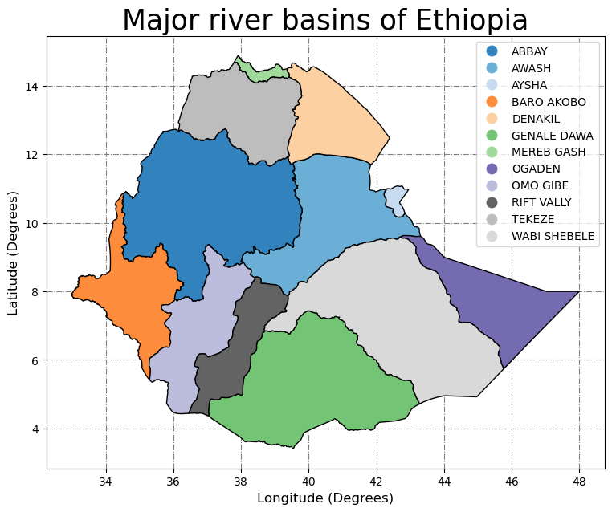

```python
fig, ax = plt.subplots(figsize=(9,7))
ET_basin.plot(alpha=1.0, cmap ='tab20c', column='BASINNAME', edgecolor='black', legend=True, ax=ax )
ax.set_title('Major river basins of Ethiopia', fontsize=25)
ax.set_axisbelow(True)
ax.yaxis.grid(color='gray', linestyle='dashdot')
ax.xaxis.grid(color='gray', linestyle='dashdot')
ax.set_xlabel("Longitude (Degrees)", fontsize=12)
ax.set_ylabel("Latitude (Degrees)", fontsize=12)
plt.savefig('basins.jpeg', transparent=True,  bbox_inches='tight', dpi=800)
plt.show()
```

Making subplots:

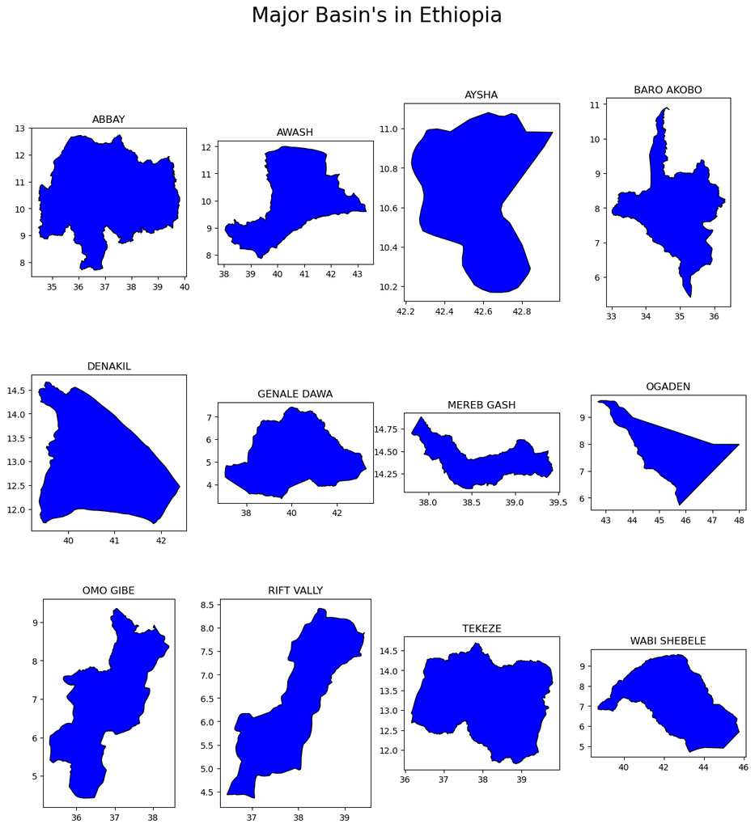

```python
fig, ((ax1, ax2, ax3, ax4), (ax5, ax6, ax7, ax8), (ax9, ax10, ax11, ax12)) = plt.subplots(3, 4, figsize=(15,15))
fig.suptitle("Major Basin's in Ethiopia", fontsize=24)
ET_basin.loc[ET_basin.BASINNAME == "ABBAY"].plot(ax=ax1, facecolor='Blue',  edgecolor='black')
ax1.set_title("ABBAY")
ET_basin.loc[ET_basin.BASINNAME == "AWASH"].plot(ax=ax2, facecolor='Blue',  edgecolor='black')
ax2.set_title("AWASH")
ET_basin.loc[ET_basin.BASINNAME == "AYSHA"].plot(ax=ax3, facecolor='Blue',  edgecolor='black')
ax3.set_title("AYSHA")
ET_basin.loc[ET_basin.BASINNAME == "BARO AKOBO"].plot(ax=ax4, facecolor='Blue',  edgecolor='black')
ax4.set_title("BARO AKOBO")
ET_basin.loc[ET_basin.BASINNAME == "DENAKIL"].plot(ax=ax5, facecolor='Blue',  edgecolor='black')
ax5.set_title("DENAKIL")
ET_basin.loc[ET_basin.BASINNAME == "GENALE DAWA"].plot(ax=ax6, facecolor='Blue',  edgecolor='black')
ax6.set_title("GENALE DAWA")
ET_basin.loc[ET_basin.BASINNAME == "MEREB GASH"].plot(ax=ax7, facecolor='Blue',  edgecolor='black')
ax7.set_title("MEREB GASH")
ET_basin.loc[ET_basin.BASINNAME == "OGADEN"].plot(ax=ax8, facecolor='Blue',  edgecolor='black')
ax8.set_title("OGADEN")
ET_basin.loc[ET_basin.BASINNAME == "OMO GIBE"].plot(ax=ax9, facecolor='Blue',  edgecolor='black')
ax9.set_title("OMO GIBE")
ET_basin.loc[ET_basin.BASINNAME == "RIFT VALLY"].plot(ax=ax10, facecolor='Blue',  edgecolor='black')
ax10.set_title("RIFT VALLY")
ET_basin.loc[ET_basin.BASINNAME == "TEKEZE"].plot(ax=ax11, facecolor='Blue',  edgecolor='black')
ax11.set_title("TEKEZE")
ET_basin.loc[ET_basin.BASINNAME == "WABI SHEBELE"].plot(ax=ax12, facecolor='Blue',  edgecolor='black')
ax12.set_title("WABI SHEBELE")
plt.show()
```

### Overlaying shapefiles

As an example, consider overlaying the ET_basin over the African continent shapefile, Let’s begin by importing the African continent shapefile:

```python
zipfile_Africa = "Africa.zip"
AFRICA = gpd.read_file(zipfile_Africa)
```

It is critical to remember that the coordinate systems of the two shapefiles must be identical. The $.crs$ command can be used to verify the coordinate system of the two shapefiles:

```python
 AFRICA.crs
```

```
<Geographic 2D CRS: EPSG:4326>
Name: WGS 84
Axis Info [ellipsoidal]:
- Lat[north]: Geodetic latitude (degree)
- Lon[east]: Geodetic longitude (degree)
Area of Use:
- name: World.
- bounds: (-180.0, -90.0, 180.0, 90.0)
Datum: World Geodetic System 1984 ensemble
- Ellipsoid: WGS 84
- Prime Meridian: Greenwich
```

```python
ET_basin.crs
```

```
<Geographic 2D CRS: EPSG:4326>
Name: WGS 84
Axis Info [ellipsoidal]:
- Lat[north]: Geodetic latitude (degree)
- Lon[east]: Geodetic longitude (degree)
Area of Use:
- name: World.
- bounds: (-180.0, -90.0, 180.0, 90.0)
Datum: World Geodetic System 1984 ensemble
- Ellipsoid: WGS 84
- Prime Meridian: Greenwich
```

You can see that they both use the WGS-84 geographic coordinate system (EPSG:4326)

Now, you can plot the overlaid map using the following code:

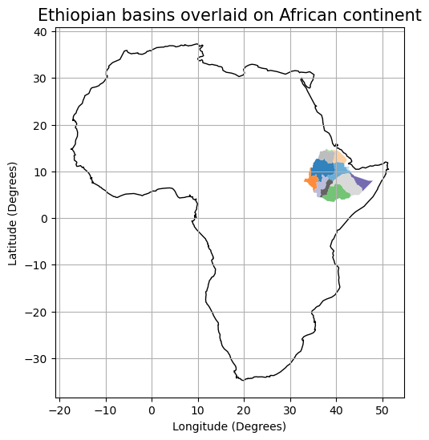

```python
fig, ax = plt.subplots(figsize=(6,6))
AFRICA.plot(ax=ax, color ='None', edgecolor='black')
ET_basin.plot(ax=ax, cmap ='tab20c', column='BASINNAME')
ax.grid(True)
ax.set_title('Ethiopian basins overlaid on African continent', fontsize=15)
ax.set(xlabel="Longitude (Degrees)", ylabel="Latitude (Degrees)")
plt.show()
```